# Statistical Computing with R: Final Portfolio

Author: Zane Sano

**MISSION LOG //** My project will use NASA meteorite landing data to explore where meteorites are found, how recorded landings have changed over time, and how meteorite mass differs across categories.

## Data Description

### 1. Identify your data source.

I will be using a dataset on meteorite landings from NASA, which I found through NASA’s Open Data Portal. The dataset contains records of meteorites that have been found or observed falling to Earth and includes their physical characteristics and geographic locations.

### 2. Describe your data, including variables and data types.

The dataset contains over 45,000 observations and includes a mix of categorical and numerical variables. These variables provide identifying information, classification details, measurements, and geographic coordinates that can be used to analyze both temporal and spatial patterns in meteorite landings.

| Name | Type | Description |
| --- | --- | --- |
| `name` | character | name of the meteorite |
| `id` | numeric | unique identifier for each meteorite |
| `nametype` | character | indicates whether the meteorite is classified as valid |
| `recclass` | character | meteorite classification type |
| `mass (g)` | numeric | mass of the meteorite |
| `fall` | character | indicates whether the meteorite was observed falling or later discovered |
| `year` | numeric | year the meteorite was recorded |
| `reclat` | numeric | latitude coordinate of the meteorite landing |
| `reclong` | numeric | longitude coordinate of the meteorite landing |
| `geoLocation` | character | combined latitude and longitude coordinates |

### 3. Identify the research questions you want to answer.

- How has the number of recorded meteorite landings and the mass of meteorites changed over time?
- How does the iron content of chondrite meteorites change across different levels of thermal alteration?
- How does meteorite mass vary across different classifications and fall types?

## Data Cleaning

### Dataset 1A & 1B

My first data set will be used to visualize the landings of meteorites on Earth and in the US across different decades. I am going to filter the original data set to remove any years after 2026 since those were incorrectly entered. I am also going to remove the columns for information I don’t need for this specific dataset. Next I am going to recreate an additional factor variable called `decades` based off the values of interest in `year`. I am also going to convert `mass_g` to `mass_kg`. I am also going to create a second data set that only includes the observations within the United States for my second map. Lastly I am going to save the cleaned data set into the correct folder.

### Dataset 2

My second visualization will display the iron content and the levels of thermal alteration of chondrite meteorites based on the Van Schmus and Wood classification, which ranks meteorites from 1 to 7 based on the degree of changes they underwent on their parent asteroid. First I am going to create a new dataset that only includes the `recclass` column, as it contains all the information I need. Next I am going to create a column that extracts the number representing the level of thermal alteration. Type 3 chondrites, also known as unequilibriated chondrites, are further broken down into subtypes. I am going to create bins for each level of the Type 3 subtypes. Then I am going to create a column that extracts the iron content of each chondrite. Lastly, I am going to save the cleaned data set into the correct folder.

## Data Visualization

### Visualization 1A

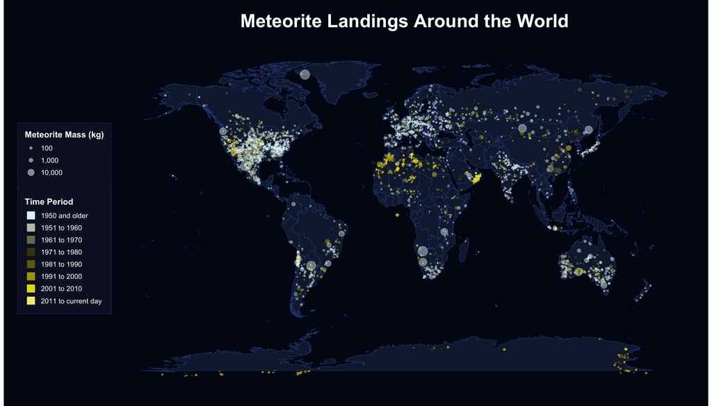

### Visualization 1b

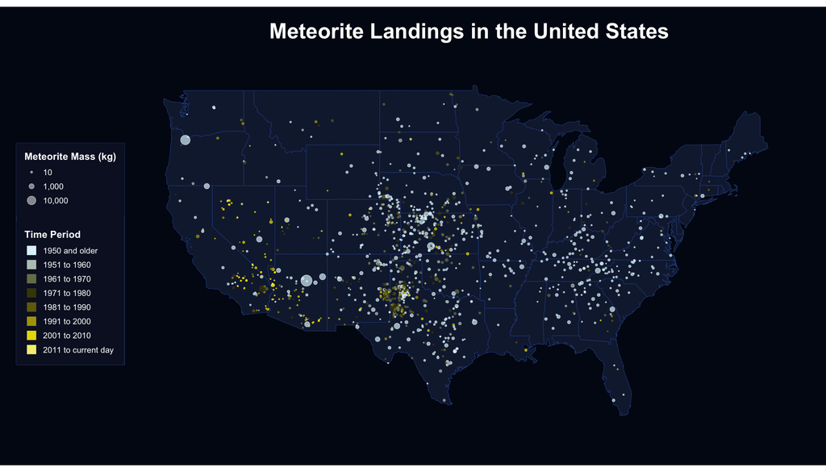

### Visualization 2

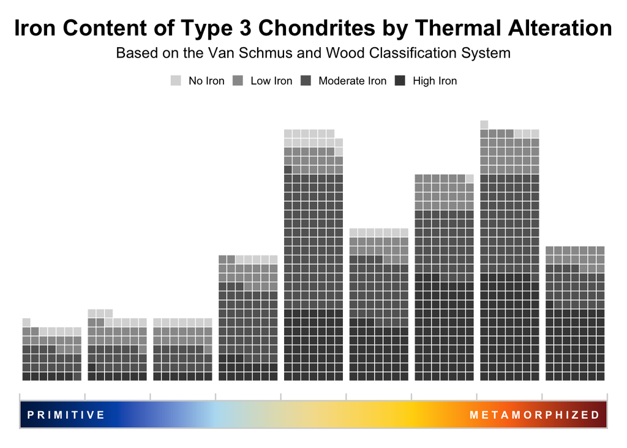